# Movie-recommendation

## **Importing the necessary libraries and overview of the dataset**

```python
# Used to ignore the warning given as output of the code
import warnings
warnings.filterwarnings('ignore')
import numpy as np
import pandas as pd
import matplotlib.pyplot as plt
import seaborn as sns
from collections import defaultdict
from surprise import accuracy
from surprise.reader import Reader
from surprise.dataset import Dataset
from surprise.model_selection import GridSearchCV
from surprise.model_selection import train_test_split
from surprise.prediction_algorithms.knns import KNNBasic
from surprise.prediction_algorithms.matrix_factorization import SVD
from surprise.model_selection import KFold
```

### **Loading the data**

```python
# Import the dataset
rating = pd.read_csv('ratings.csv')
#rating = pd.read_csv('/content/drive/MyDrive/ratings.csv') # Uncomment this line code if you are using google colab.
```

Let's check the **info** of the data

```python
rating.info()
```

```
<class 'pandas.core.frame.DataFrame'>
RangeIndex: 100004 entries, 0 to 100003
Data columns (total 4 columns):
 #   Column     Non-Null Count   Dtype
---  ------     --------------   -----
 0   userId     100004 non-null  int64
 1   movieId    100004 non-null  int64
 2   rating     100004 non-null  float64
 3   timestamp  100004 non-null  int64
dtypes: float64(1), int64(3)
memory usage: 3.1 MB
```

- There are **100,004 observations** and **4 columns** in the data
- All the columns are of **numeric data type**
- The data type of the timestamp column is int64 which is not correct. We can convert this to DateTime format but **we don't need timestamp for our analysis**. Hence, **we can drop this column**

```python
# Dropping timestamp column
rating = rating.drop(['timestamp'], axis=1)
```

```python
rating.head(5)
```

|  | userId | movieId | rating |
| --- | --- | --- | --- |
| 0 | 1 | 31 | 2.5 |
| 1 | 1 | 1029 | 3.0 |
| 2 | 1 | 1061 | 3.0 |
| 3 | 1 | 1129 | 2.0 |
| 4 | 1 | 1172 | 4.0 |

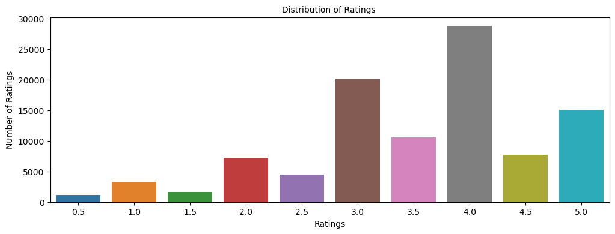

```python
plt.figure(figsize = (12, 4))

sns.countplot(data = rating, x = "rating")

plt.tick_params(labelsize = 10)
plt.title("Distribution of Ratings ", fontsize = 10)
plt.xlabel("Ratings", fontsize = 10)
plt.ylabel("Number of Ratings", fontsize = 10)
plt.show()
```

### Findings

1. Users do not typically dislike a move.
2. There is a lot of 4 star ratings.
3. more obviously As per Histogram, Rating '4' has highest count of ratings 25000+ .Rating '3' being second with 20000 and Rating '5' being third in count of ratings being in the range of 15000.

```python
# Finding number of unique users
len(rating['userId'].unique())
```

```
671
```

there is 671 unique users in the list.

```python
# Finding number of unique movies

len(rating['movieId'].unique())
```

```
9066
```

there is 9,066 unique movies in the list.

```python
rating.groupby(['userId', 'movieId']).count()
```

| userId | movieId | rating |
| --- | --- | --- |
| 1 | 31 | 1 |
|  | 1029 | 1 |
|  | 1061 | 1 |
|  | 1129 | 1 |
|  | 1172 | 1 |
| ... | ... | ... |
| 671 | 6268 | 1 |
|  | 6269 | 1 |
|  | 6365 | 1 |
|  | 6385 | 1 |
|  | 6565 | 1 |

100004 rows × 1 columns

```python
rating.groupby(['userId', 'movieId']).count()['rating'].sum()
```

```
100004
```

```python
rating['movieId'].mode()
```

```
0    356
Name: movieId, dtype: int64
```

356 Is the most interacted movie

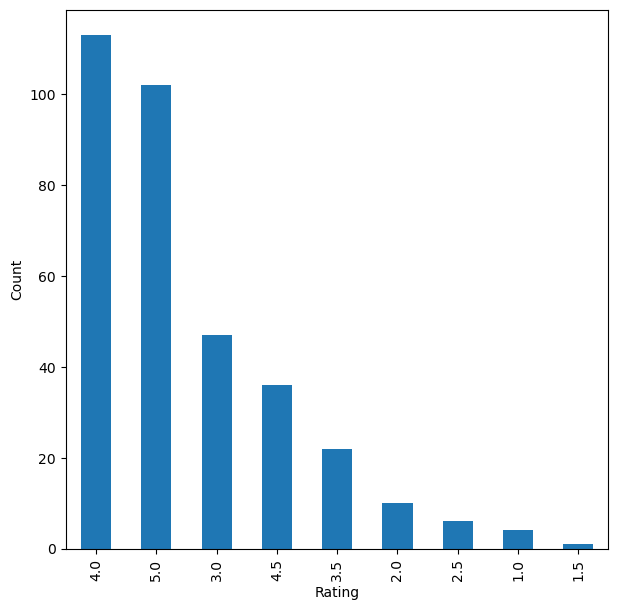

```python
# Plotting distributions of ratings for 341 interactions with movieid 356
plt.figure(figsize=(7,7))

rating[rating['movieId'] == 356]['rating'].value_counts().plot(kind='bar')

plt.xlabel('Rating')

plt.ylabel('Count')

plt.show()
```

```python
rating['userId'].mode()
```

```
0    547
Name: userId, dtype: int64
```

- the most common user seen in the database is user 547 which implies that this user interacts with any movie the most out of everyone.

```python
# Finding user-movie interactions distribution
count_interactions = rating.groupby('userId').count()['movieId']
count_interactions
```

```
userId
1       20
2       76
3       51
4      204
5      100
      ...
667     68
668     20
669     37
670     31
671    115
Name: movieId, Length: 671, dtype: int64
```

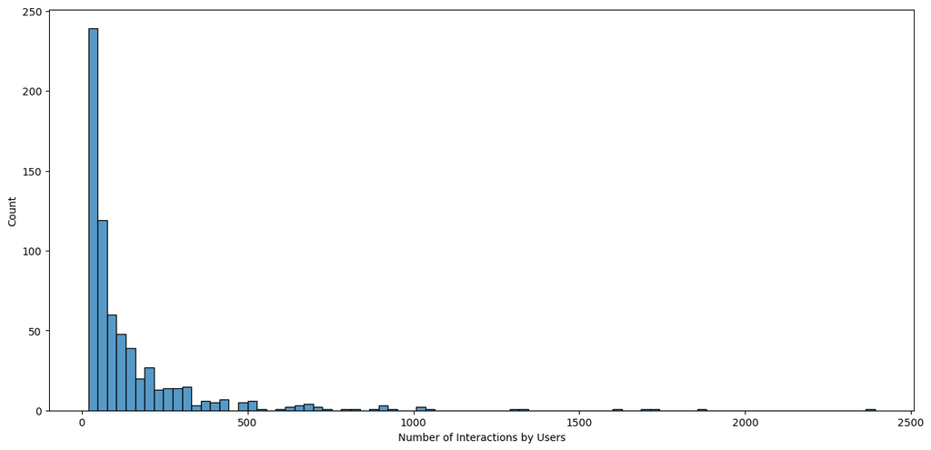

```python
# Plotting user-movie interactions distribution

plt.figure(figsize=(15,7))

sns.histplot(data = count_interactions)

plt.xlabel('Number of Interactions by Users')

plt.show()
```

**user movie interaction distribution**

1. the data is very right skewed
2. most users typically rate very few movies
3. very few users have over 200 interactions

### **Model 1: Rank-Based Recommendation System**

To build the rank-based recommendation system, take the **average** of all the ratings provided to each movie and then rank them based on their average rating.

```python
# Calculating average ratings
average_rating = rating.groupby('movieId').mean()["rating"]

# Calculating the count of ratings
count_rating = rating.groupby('movieId').count()["rating"]

# Making a dataframe with the count and average of ratings
final_rating = pd.DataFrame({'avg_rating':average_rating, 'rating_count':count_rating})
```

```python
final_rating.head()
```

| movieId | avg_rating | rating_count |
| --- | --- | --- |
| 1 | 3.872470 | 247 |
| 2 | 3.401869 | 107 |
| 3 | 3.161017 | 59 |
| 4 | 2.384615 | 13 |
| 5 | 3.267857 | 56 |

Now, creating a function to find **top n movies** for a recommendation based on the average ratings of movies. adding a **threshold for a minimum number of interactions** for a movie to be considered for recommendation.

```python
def top_n_movies(data, n, min_interaction=100):

    #Finding movies with minimum number of interactions
    recommendations = data[data['rating_count'] >= min_interaction]

    #Sorting values w.r.t average rating
    recommendations = recommendations.sort_values(by='avg_rating', ascending=False)

    return recommendations.index[:n]
```

#### **Recommending top 5 movies with 200 minimum interactions based on popularity**

```python
list(top_n_movies(final_rating, 5, min_interaction=200))
```

```
[858, 318, 50, 527, 608]
```

## **Model 2: User based Collaborative Filtering Recommendation System**

#### **Making the dataset into surprise dataset and splitting it into train and test set**

```python
# Instantiating Reader scale with expected rating scale
reader = Reader(rating_scale=(0, 5))

# Loading the rating dataset
data = Dataset.load_from_df(rating[['userId', 'movieId', 'rating']], reader)

# Splitting the data into train and test dataset
trainset, testset = train_test_split(data, test_size=0.2, random_state=42)
```

#### **Build the first baseline similarity based recommendation system using cosine similarity and KNN**

```python
sim_options = {'name': 'cosine',
               'user_based' : True}

# Defining Nearest neighbour algorithm
algo_knn_user = KNNBasic(sim_options=sim_options, verbose = False)

# Train the algorithm on the trainset or fitting the model on train dataset
algo_knn_user.fit(trainset)

# Predict ratings for the testset
predictions = algo_knn_user.test(testset)

# Then compute RMSE
accuracy.rmse(predictions)
```

```
RMSE: 0.9925
```

```
0.9924509041520163
```

- the baseline model has RMSE=0.9924 on test set.

```python
algo_knn_user.predict(4, 10, r_ui=4, verbose=True)
```

```
user: 4          item: 10         r_ui = 4.00   est = 3.62   {'actual_k': 40, 'was_impossible': False}
```

```
Prediction(uid=4, iid=10, r_ui=4, est=3.6244912065910952, details={'actual_k': 40, 'was_impossible': False})
```

- As we can see - the actual rating for this user-movie pair is 4 and predicted rating is 3.62 by this similarity based baseline model

Let's predict the rating for the same `userId=4` but for a movie which this user has not interacted before i.e. `movieId=3`

```python
algo_knn_user.predict(4, 3, verbose=True)
```

```
user: 4          item: 3          r_ui = None   est = 3.20   {'actual_k': 40, 'was_impossible': False}
```

```
Prediction(uid=4, iid=3, r_ui=None, est=3.202703552548654, details={'actual_k': 40, 'was_impossible': False})
```

- based on the similarity based baseline model, The estimated rating for the user-movie pair is 3.2

### **Improving user-user similarity based recommendation system by tuning its hyper-parameters**

```python
# Setting up parameter grid to tune the hyperparameters
param_grid = {'k': [20,30,40], 'min_k': [3,6,9],
               'sim_options': {'name': ['msd', 'cosine'],
               'user_based': [True]}}

# Performing 3-fold cross validation to tune the hyperparameters
grid_obj = GridSearchCV(KNNBasic, param_grid, measures=['rmse', 'mae'], cv=3, n_jobs=-1)

# Fitting the data
grid_obj.fit(data)

# Best RMSE score
print(grid_obj.best_score['rmse'])

# Combination of parameters that gave the best RMSE score
print(grid_obj.best_params['rmse'])
```

[output not shown]

[output cut: 55 more lines]

```
Computing the msd similarity matrix...
Done computing similarity matrix.
Done computing similarity matrix.
Computing the msd similarity matrix...
Done computing similarity matrix.
Computing the msd similarity matrix...
Done computing similarity matrix.
Computing the cosine similarity matrix...
Done computing similarity matrix.
Computing the cosine similarity matrix...
Computing the cosine similarity matrix...
Done computing similarity matrix.
Done computing similarity matrix.
0.9646259782062044
{'k': 20, 'min_k': 3, 'sim_options': {'name': 'msd', 'user_based': True}}
```

```python
results_df = pd.DataFrame.from_dict(grid_obj.cv_results)
results_df.head()
```

|  | split0_test_rmse | split1_test_rmse | split2_test_rmse | mean_test_rmse | std_test_rmse | rank_test_rmse | split0_test_mae | split1_test_mae | split2_test_mae | mean_test_mae | std_test_mae | rank_test_mae | mean_fit_time | std_fit_time | mean_test_time | std_test_time | params | param_k | param_min_k | param_sim_options |
| --- | --- | --- | --- | --- | --- | --- | --- | --- | --- | --- | --- | --- | --- | --- | --- | --- | --- | --- | --- | --- |
| 0 | 0.966532 | 0.967888 | 0.959458 | 0.964626 | 0.003696 | 1 | 0.743390 | 0.743449 | 0.738705 | 0.741848 | 0.002223 | 1 | 0.068388 | 0.008233 | 1.184296 | 0.018953 | {'k': 20, 'min_k': 3, 'sim_options': {'name': ... | 20 | 3 | {'name': 'msd', 'user_based': True} |
| 1 | 0.996202 | 0.997241 | 0.988302 | 0.993915 | 0.003991 | 14 | 0.769805 | 0.770608 | 0.764896 | 0.768436 | 0.002525 | 12 | 0.053699 | 0.009375 | 1.261041 | 0.078426 | {'k': 20, 'min_k': 3, 'sim_options': {'name': ... | 20 | 3 | {'name': 'cosine', 'user_based': True} |
| 2 | 0.969110 | 0.971205 | 0.963988 | 0.968101 | 0.003031 | 3 | 0.745023 | 0.746462 | 0.742055 | 0.744514 | 0.001835 | 3 | 0.040217 | 0.013597 | 1.198865 | 0.048414 | {'k': 20, 'min_k': 6, 'sim_options': {'name': ... | 20 | 6 | {'name': 'msd', 'user_based': True} |
| 3 | 0.997310 | 0.999021 | 0.991574 | 0.995968 | 0.003185 | 15 | 0.770372 | 0.772310 | 0.767197 | 0.769960 | 0.002108 | 15 | 0.066337 | 0.010722 | 1.129475 | 0.074297 | {'k': 20, 'min_k': 6, 'sim_options': {'name': ... | 20 | 6 | {'name': 'cosine', 'user_based': True} |
| 4 | 0.974840 | 0.978181 | 0.971766 | 0.974929 | 0.002620 | 7 | 0.749616 | 0.752636 | 0.748301 | 0.750184 | 0.001815 | 7 | 0.041211 | 0.006149 | 1.194134 | 0.085914 | {'k': 20, 'min_k': 9, 'sim_options': {'name': ... | 20 | 9 | {'name': 'msd', 'user_based': True} |

```python
sim_options = {'name': 'cosine',
               'user_based': True}
# Creating an instance of KNNBasic with optimal hyperparameter values
similarity_algo_optimized_user = KNNBasic(sim_options = sim_options,verbose=False)

# Training the algorithm on the trainset
similarity_algo_optimized_user.fit(trainset)

# Predicting ratings for the testset
predictions = similarity_algo_optimized_user.test(testset)

# Computing RMSE on testset
accuracy.rmse(predictions)
```

```
RMSE: 0.9925
```

```
0.9924509041520163
```

Let's us now predict rating for an user with `userId=4` and for `movieId=10` with the optimized model

```python
similarity_algo_optimized_user.predict(4,10, r_ui=4, verbose=True)
```

```
user: 4          item: 10         r_ui = 4.00   est = 3.62   {'actual_k': 40, 'was_impossible': False}
```

```
Prediction(uid=4, iid=10, r_ui=4, est=3.6244912065910952, details={'actual_k': 40, 'was_impossible': False})
```

Below we are predicting rating for the same `userId=4` but for a movie which this user has not interacted before i.e. `movieId=3`, by using the optimized model as shown below -

```python
similarity_algo_optimized_user.predict(4,3, verbose=True)
```

```
user: 4          item: 3          r_ui = None   est = 3.20   {'actual_k': 40, 'was_impossible': False}
```

```
Prediction(uid=4, iid=3, r_ui=None, est=3.202703552548654, details={'actual_k': 40, 'was_impossible': False})
```

```python
similarity_algo_optimized_user.get_neighbors(4, k=5)
```

```
[357, 220, 590, 491, 647]
```

### **Implementing the recommendation algorithm based on optimized KNNBasic model**

```python
def get_recommendations(data, user_id, top_n, algo):
    recommendations = []
    user_item_interactions_matrix = data.pivot(index='userId', columns='movieId', values='rating')
    # Extracting those movie ids which the user_id has not interacted yet
    non_interacted_movies = user_item_interactions_matrix.loc[user_id][user_item_interactions_matrix.loc[user_id].isnull()].index.tolist()

    # Looping through each of the movie id which user_id has not interacted yet
    for item_id in non_interacted_movies:
        # Predicting the ratings for those non interacted movie ids by this user
        est = algo.predict(user_id, item_id).est
        # Appending the predicted ratings
        recommendations.append((item_id, est))
    # Sorting the predicted ratings in descending order
    recommendations.sort(key=lambda x: x[1], reverse=True)

    return recommendations[:top_n] # returing top n highest predicted rating movies for this user
```

#### **Predicted top 5 movies for userId=4 with similarity based recommendation system**

```python
recommendations = get_recommendations(rating,4,5,similarity_algo_optimized_user)
```

```python
recommendations
```

```
[(53, 5), (183, 5), (301, 5), (309, 5), (363, 5)]
```

## **Model 3: Item based Collaborative Filtering Recommendation System**

```python
# Definfing similarity measure
sim_options = {'name': 'cosine',
               'user_based': False}

# Defining Nearest neighbour algorithm
algo_knn_item = KNNBasic(sim_options= sim_options,verbose=False)

# Train the algorithm on the trainset or fitting the model on train dataset
algo_knn_item.fit(trainset)

# Predict ratings for the testset
predictions = algo_knn_item.test(testset)

# Then compute RMSE
accuracy.rmse(predictions)
```

```
RMSE: 1.0032
```

```
1.003221450633729
```

- As we can see from above, the baseline model has RMSE=1.003 on test set

```python
algo_knn_item.predict(4,10, r_ui=4, verbose=True)
algo_knn_item.predict(4,3, r_ui=4, verbose=True)
```

```
user: 4          item: 10         r_ui = 4.00   est = 4.37   {'actual_k': 40, 'was_impossible': False}
user: 4          item: 3          r_ui = 4.00   est = 4.07   {'actual_k': 40, 'was_impossible': False}
```

```
Prediction(uid=4, iid=3, r_ui=4, est=4.071601862880049, details={'actual_k': 40, 'was_impossible': False})
```

- as shown above the estimated rating for user liking movieId 10 is **4.37/5**
- UserId 4 is estimated to rate movieId 3 **4.07/5**

Let's predict the rating for the same `userId=4` but for a movie which this user has not interacted before i.e. `movieId=3`

```python
algo_knn_item.predict(4,3, verbose=True)
```

```
user: 4          item: 3          r_ui = None   est = 4.07   {'actual_k': 40, 'was_impossible': False}
```

```
Prediction(uid=4, iid=3, r_ui=None, est=4.071601862880049, details={'actual_k': 40, 'was_impossible': False})
```

- According to the model User 4 will likely rate movieId 3 a **4.07/5**

## Hyperparameter tuning for RMSE

```python
param_grid = {'k': [20, 30, 40], 'min_k': [3,6,9], 'sim_options': {'name' : ['msd', 'cosine'],
                                                                   'user_based': [False]}}

# Performing 3-fold cross validation to tune the hyperparameters
grid_obj = GridSearchCV(KNNBasic, param_grid, measures=['rmse', 'mae'], cv=3, n_jobs=-1)

# Fitting the data
grid_obj.fit(data)

# Best RMSE score
print(grid_obj.best_score['rmse'])

# Combination of parameters that gave the best RMSE score
print(grid_obj.best_params['rmse'])
```

[output not shown]

[output cut: 55 more lines]

```
Computing the msd similarity matrix...
Done computing similarity matrix.
Done computing similarity matrix.
Computing the cosine similarity matrix...
Done computing similarity matrix.
Done computing similarity matrix.
Computing the cosine similarity matrix...
Done computing similarity matrix.
Done computing similarity matrix.
Computing the cosine similarity matrix...
Done computing similarity matrix.
Done computing similarity matrix.
Done computing similarity matrix.
0.941288142363347
{'k': 40, 'min_k': 3, 'sim_options': {'name': 'msd', 'user_based': False}}
```

Below we are analysing evaluation metrics - RMSE and MAE at each and every split to analyze the impact of each value of hyperparameters

```python
results_df = pd.DataFrame.from_dict(grid_obj.cv_results)
results_df.head()
```

|  | split0_test_rmse | split1_test_rmse | split2_test_rmse | mean_test_rmse | std_test_rmse | rank_test_rmse | split0_test_mae | split1_test_mae | split2_test_mae | mean_test_mae | std_test_mae | rank_test_mae | mean_fit_time | std_fit_time | mean_test_time | std_test_time | params | param_k | param_min_k | param_sim_options |
| --- | --- | --- | --- | --- | --- | --- | --- | --- | --- | --- | --- | --- | --- | --- | --- | --- | --- | --- | --- | --- |
| 0 | 0.950005 | 0.953504 | 0.953503 | 0.952337 | 0.001649 | 7 | 0.732995 | 0.736407 | 0.736340 | 0.735247 | 0.001593 | 7 | 12.407956 | 0.151840 | 9.615959 | 0.237127 | {'k': 20, 'min_k': 3, 'sim_options': {'name': ... | 20 | 3 | {'name': 'msd', 'user_based': False} |
| 1 | 1.012080 | 1.014571 | 1.019947 | 1.015533 | 0.003283 | 16 | 0.789473 | 0.792267 | 0.796092 | 0.792611 | 0.002713 | 16 | 21.137609 | 0.025321 | 9.718243 | 0.210902 | {'k': 20, 'min_k': 3, 'sim_options': {'name': ... | 20 | 3 | {'name': 'cosine', 'user_based': False} |
| 2 | 0.951144 | 0.953575 | 0.953382 | 0.952700 | 0.001103 | 8 | 0.733859 | 0.736471 | 0.736327 | 0.735553 | 0.001199 | 8 | 10.089517 | 3.455126 | 10.128261 | 1.402336 | {'k': 20, 'min_k': 6, 'sim_options': {'name': ... | 20 | 6 | {'name': 'msd', 'user_based': False} |
| 3 | 1.013198 | 1.014696 | 1.019861 | 1.015918 | 0.002854 | 17 | 0.790335 | 0.792375 | 0.796078 | 0.792929 | 0.002377 | 17 | 20.849862 | 0.159455 | 9.439012 | 0.240451 | {'k': 20, 'min_k': 6, 'sim_options': {'name': ... | 20 | 6 | {'name': 'cosine', 'user_based': False} |
| 4 | 0.951689 | 0.953672 | 0.953511 | 0.952957 | 0.000899 | 9 | 0.734193 | 0.736791 | 0.736561 | 0.735848 | 0.001174 | 9 | 7.320670 | 1.298409 | 11.018185 | 0.857073 | {'k': 20, 'min_k': 9, 'sim_options': {'name': ... | 20 | 9 | {'name': 'msd', 'user_based': False} |

```python
# Creating an instance of KNNBasic with optimal hyperparameter values
similarity_algo_optimized_item = KNNBasic(sim_options={'name': 'msd', 'user_base': False}
                                          , k=30, min_k=6,verbose=False)

# Training the algorithm on the trainset
similarity_algo_optimized_item.fit(trainset)

# Predicting ratings for the testset
predictions = similarity_algo_optimized_item.test(testset)

# Computing RMSE on testset
accuracy.rmse(predictions)
```

```
RMSE: 0.9649
```

```
0.9648695560524467
```

Let's us now predict rating for an user with `userId=4` and for `movieId=10` with the optimized model as shown below

```python
similarity_algo_optimized_item.predict(4,10, r_ui=4, verbose=True)
```

```
user: 4          item: 10         r_ui = 4.00   est = 3.71   {'actual_k': 30, 'was_impossible': False}
```

```
Prediction(uid=4, iid=10, r_ui=4, est=3.7130360608903943, details={'actual_k': 30, 'was_impossible': False})
```

Let's predict the rating for the same `userId=4` but for a movie which this user has not interacted before i.e. `movieId=3`, by using the optimized model:

```python
similarity_algo_optimized_item.predict(4, 3, verbose=True)
```

```
user: 4          item: 3          r_ui = None   est = 3.45   {'actual_k': 30, 'was_impossible': False}
```

```
Prediction(uid=4, iid=3, r_ui=None, est=3.4483196919285954, details={'actual_k': 30, 'was_impossible': False})
```

- According to the model User 4 will likely rate movieId 3 a **3.45/5**

```python
similarity_algo_optimized_item.get_neighbors(3, k=5)
```

```
[118, 296, 478, 573, 576]
```

#### **Predicted top 5 movies for userId=4 with similarity based recommendation system**

```python
recommendations = get_recommendations(rating, 4, 5, similarity_algo_optimized_item)
```

### **Predict the top 5 movies for userId=4 with similarity based recommendation system**

```python
recommendations
```

```
[(98491, 4.863224466679252),
 (1192, 4.803341471563519),
 (6669, 4.794608813756791),
 (116, 4.793891781356206),
 (1221, 4.741084623269258)]
```

## **Model 4: Based Collaborative Filtering - Matrix Factorization using SVD**

```python
# Using SVD matrix factorization
algo_svd = SVD()

# Training the algorithm on the trainset
algo_svd.fit(trainset)

# Predicting ratings for the testset
predictions = algo_svd.test(testset)

# Computing RMSE on the testset
accuracy.rmse(predictions)
```

```
RMSE: 0.9033
```

```
0.9033354495602317
```

Let's us now predict rating for an user with `userId=4` and for `movieId=10`

```python
algo_svd.predict(4,10, r_ui=4, verbose=True)
```

```
user: 4          item: 10         r_ui = 4.00   est = 4.20   {'was_impossible': False}
```

```
Prediction(uid=4, iid=10, r_ui=4, est=4.199278155020397, details={'was_impossible': False})
```

- the actual rating for this user-item pair is 4 and predicted rating is 4.20 by this matrix factorization based baseline model

Let's predict the rating for the same `userId=4` but for a movie which this user has not interacted before i.e. `movieId=3`:

```python
algo_svd.predict(4, 3, verbose=True)
```

```
user: 4          item: 3          r_ui = None   est = 3.75   {'was_impossible': False}
```

```
Prediction(uid=4, iid=3, r_ui=None, est=3.7504369637593924, details={'was_impossible': False})
```

the estimated rating for this user-item pair is 3.75 based on this matrix factorization model.

### **Improving matrix factorization based recommendation system by tuning its hyper-parameters**

```python
# Set the parameter space to tune
param_grid = {'n_epochs': [10, 20, 30], 'lr_all': [0.001, 0.005, 0.01],
              'reg_all': [0.2, 0.4, 0.6]}

# Performing 3-fold gridsearch cross validation
gs = GridSearchCV(SVD, param_grid, measures=['rmse', 'mae'], cv=3, n_jobs=-1)

# Fitting data
gs.fit(data)

# Best RMSE score
print(gs.best_score['rmse'])

# Combination of parameters that gave the best RMSE score
print(gs.best_params['rmse'])
```

```
0.8936577859185507
{'n_epochs': 30, 'lr_all': 0.01, 'reg_all': 0.2}
```

Below we are analysing evaluation metrics - RMSE and MAE at each and every split to analyze the impact of each value of hyperparameters

```python
results_df = pd.DataFrame.from_dict(gs.cv_results)
results_df.head()
```

|  | split0_test_rmse | split1_test_rmse | split2_test_rmse | mean_test_rmse | std_test_rmse | rank_test_rmse | split0_test_mae | split1_test_mae | split2_test_mae | mean_test_mae | std_test_mae | rank_test_mae | mean_fit_time | std_fit_time | mean_test_time | std_test_time | params | param_n_epochs | param_lr_all | param_reg_all |
| --- | --- | --- | --- | --- | --- | --- | --- | --- | --- | --- | --- | --- | --- | --- | --- | --- | --- | --- | --- | --- |
| 0 | 0.943387 | 0.947940 | 0.937596 | 0.942974 | 0.004233 | 25 | 0.737427 | 0.741901 | 0.735161 | 0.738163 | 0.002800 | 25 | 0.258792 | 0.036248 | 0.214878 | 0.017663 | {'n_epochs': 10, 'lr_all': 0.001, 'reg_all': 0.2} | 10 | 0.001 | 0.2 |
| 1 | 0.948089 | 0.952855 | 0.942098 | 0.947681 | 0.004401 | 26 | 0.742726 | 0.747195 | 0.740174 | 0.743365 | 0.002902 | 26 | 0.374146 | 0.006301 | 0.207856 | 0.009700 | {'n_epochs': 10, 'lr_all': 0.001, 'reg_all': 0.4} | 10 | 0.001 | 0.4 |
| 2 | 0.952610 | 0.957929 | 0.946976 | 0.952505 | 0.004472 | 27 | 0.747749 | 0.752682 | 0.745575 | 0.748669 | 0.002974 | 27 | 0.389210 | 0.054778 | 0.225928 | 0.017738 | {'n_epochs': 10, 'lr_all': 0.001, 'reg_all': 0.6} | 10 | 0.001 | 0.6 |
| 3 | 0.907975 | 0.910199 | 0.902025 | 0.906733 | 0.003451 | 11 | 0.702017 | 0.705049 | 0.700181 | 0.702416 | 0.002008 | 9 | 0.361631 | 0.016825 | 0.207158 | 0.018945 | {'n_epochs': 10, 'lr_all': 0.005, 'reg_all': 0.2} | 10 | 0.005 | 0.2 |
| 4 | 0.914438 | 0.917519 | 0.909128 | 0.913695 | 0.003466 | 15 | 0.709342 | 0.713026 | 0.707734 | 0.710034 | 0.002215 | 15 | 0.352148 | 0.020535 | 0.208246 | 0.013440 | {'n_epochs': 10, 'lr_all': 0.005, 'reg_all': 0.4} | 10 | 0.005 | 0.4 |

Now, we will **the build final model** by using **tuned values** of the hyperparameters, which we received using grid search cross-validation above.

```python
# Building the optimized SVD model using optimal hyperparameter search
svd_algo_optimized = SVD(n_epochs=30, lr_all=0.01, reg_all=0.2)

# Training the algorithm on the trainset
svd_algo_optimized.fit(trainset)

# Predicting ratings for the testset
predictions = svd_algo_optimized.test(testset)

# Computing RMSE
accuracy.rmse(predictions)
```

```
RMSE: 0.8950
```

```
0.8949892365162011
```

Let's us now predict rating for an user with `userId=4` and for `movieId=10` with the optimized model

```python
svd_algo_optimized.predict(4, 10, r_ui=4, verbose=True)
```

```
user: 4          item: 10         r_ui = 4.00   est = 3.99   {'was_impossible': False}
```

```
Prediction(uid=4, iid=10, r_ui=4, est=3.991504240118864, details={'was_impossible': False})
```

- the predicted rating is 3.99

Let's predict the rating for the same `userId=4` but for a movie which this user has not interacted before i.e. `movieId=3`:

```python
svd_algo_optimized.predict(4, 3, verbose=True)
```

```
user: 4          item: 3          r_ui = None   est = 3.64   {'was_impossible': False}
```

```
Prediction(uid=4, iid=3, r_ui=None, est=3.6383671270134244, details={'was_impossible': False})
```

```python
get_recommendations(rating, 4, 5, svd_algo_optimized)
```

```
[(1192, 5),
 (116, 4.972675682179062),
 (3310, 4.955798899644724),
 (926, 4.938952054982838),
 (1948, 4.9279474390855205)]
```

### **Predicting ratings for already interacted movies**

Below we are comparing the rating predictions of users for those movies which has been already watched by an user. This will help us to understand how well are predictions are as compared to the actual ratings provided by users

```python
def predict_already_interacted_ratings(data, user_id, algo):
    recommendations = []
    user_item_interactions_matrix = data.pivot(index='userId', columns='movieId', values='rating')
    # Extracting those movie ids which the user_id has interacted already
    interacted_movies = user_item_interactions_matrix.loc[user_id][user_item_interactions_matrix.loc[user_id].notnull()].index.tolist()

    # Looping through each of the movie id which user_id has interacted already
    for item_id in interacted_movies:
        # Extracting actual ratings
        actual_rating = user_item_interactions_matrix.loc[user_id, item_id]
        # Predicting the ratings for those non interacted movie ids by this user
        predicted_rating = algo.predict(user_id, item_id).est
        # Appending the predicted ratings
        recommendations.append((item_id, actual_rating, predicted_rating))

    # Sorting the predicted ratings in descending order
    recommendations.sort(key=lambda x: x[1], reverse=True)

    return pd.DataFrame(recommendations, columns=['movieId', 'actual_rating', 'predicted_rating']) # returing top n highest predicted rating movies for this user
```

Here we are comparing the predicted ratings by `similarity based recommendation` system against actual ratings for `userId=7`

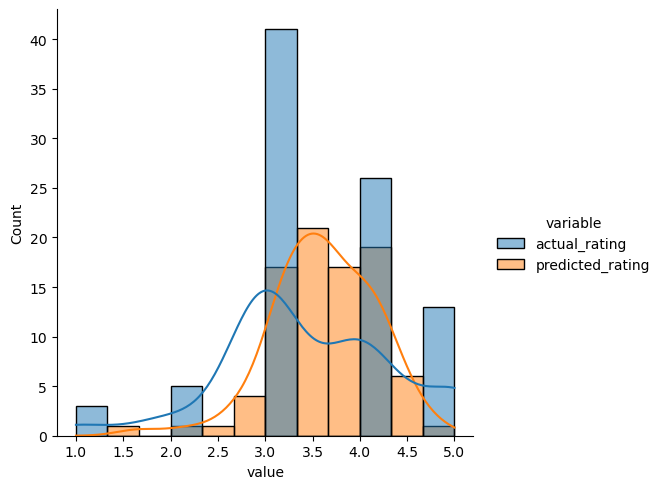

```python
predicted_ratings_for_interacted_movies = predict_already_interacted_ratings(rating, 7, similarity_algo_optimized_item)
df = predicted_ratings_for_interacted_movies.melt(id_vars='movieId', value_vars=['actual_rating', 'predicted_rating'])
sns.displot(data=df, x='value', hue='variable', kde=True);
```

- We can see that distribution of predicted ratings is closely following the distribution ofactual ratings.
- The total bins for predicted ratings are nearly same as to the total bins for actual ratings.
- We are getting more predicted values in between 3 and 4.

Below we are comparing the predicted ratings by `matrix factorization based recommendation` system against actual ratings for `userId=7`

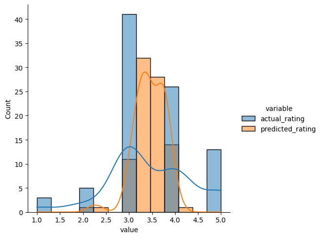

```python
predicted_ratings_for_interacted_movies = predict_already_interacted_ratings(rating, 7, svd_algo_optimized)
df = predicted_ratings_for_interacted_movies.melt(id_vars='movieId', value_vars=['actual_rating', 'predicted_rating'])
sns.displot(data=df, x='value', hue='variable', kde=True);
```

```python
# Instantiating Reader scale with expected rating scale
reader = Reader(rating_scale=(0, 5))

# Loading the rating dataset
data = Dataset.load_from_df(rating[['userId', 'movieId', 'rating']], reader)

# Splitting the data into train and test dataset
trainset, testset = train_test_split(data, test_size=0.2, random_state=42)
```

### **Compute the precision and recall, for each of the 6 models, at k = 5 and 10.**

```python
# Function can be found on surprise documentation FAQs
def precision_recall_at_k(predictions, k=10, threshold=3.5):
    """Return precision and recall at k metrics for each user"""

    # First map the predictions to each user.
    user_est_true = defaultdict(list)
    for uid, _, true_r, est, _ in predictions:
        user_est_true[uid].append((est, true_r))

    precisions = dict()
    recalls = dict()
    for uid, user_ratings in user_est_true.items():

        # Sort user ratings by estimated value
        user_ratings.sort(key=lambda x: x[0], reverse=True)

        # Number of relevant items
        n_rel = sum((true_r >= threshold) for (_, true_r) in user_ratings)

        # Number of recommended items in top k
        n_rec_k = sum((est >= threshold) for (est, _) in user_ratings[:k])

        # Number of relevant and recommended items in top k
        n_rel_and_rec_k = sum(((true_r >= threshold) and (est >= threshold))
                              for (est, true_r) in user_ratings[:k])

        # Precision@K: Proportion of recommended items that are relevant
        # When n_rec_k is 0, Precision is undefined. We here set it to 0.

        precisions[uid] = n_rel_and_rec_k / n_rec_k if n_rec_k != 0 else 0

        # Recall@K: Proportion of relevant items that are recommended
        # When n_rel is 0, Recall is undefined. We here set it to 0.

        recalls[uid] = n_rel_and_rec_k / n_rel if n_rel != 0 else 0

    return precisions, recalls
```

```python
# A basic cross-validation iterator.
kf = KFold(n_splits=5)
K = [5, 10]
models = [algo_knn_user, similarity_algo_optimized_user, algo_knn_item, similarity_algo_optimized_item, algo_svd, svd_algo_optimized]

for k in K:
    for model in models:
        print('> k={}, model={}'.format(k,model.__class__.__name__))
        p = []
        r = []
        for trainset, testset in kf.split(data):
            model.fit(trainset)
            predictions = model.test(testset, verbose=False)
            precisions, recalls = precision_recall_at_k(predictions, k=k, threshold=3.5)

            # Precision and recall can then be averaged over all users
            p.append(sum(prec for prec in precisions.values()) / len(precisions))
            r.append(sum(rec for rec in recalls.values()) / len(recalls))

        print('-----> Precision: ', round(sum(p) / len(p), 3))
        print('-----> Recall: ', round(sum(r) / len(r), 3))
```

```
> k=5, model=KNNBasic
-----> Precision:  0.767
-----> Recall:  0.413
> k=5, model=KNNBasic
-----> Precision:  0.767
-----> Recall:  0.409
> k=5, model=KNNBasic
-----> Precision:  0.61
-----> Recall:  0.328
> k=5, model=KNNBasic
-----> Precision:  0.779
-----> Recall:  0.422
> k=5, model=SVD
-----> Precision:  0.756
-----> Recall:  0.384
> k=5, model=SVD
-----> Precision:  0.747
-----> Recall:  0.386
> k=10, model=KNNBasic
-----> Precision:  0.745
-----> Recall:  0.547
> k=10, model=KNNBasic
-----> Precision:  0.75
-----> Recall:  0.55
> k=10, model=KNNBasic
-----> Precision:  0.598
-----> Recall:  0.478
> k=10, model=KNNBasic
-----> Precision:  0.753
-----> Recall:  0.568
> k=10, model=SVD
-----> Precision:  0.734
-----> Recall:  0.516
> k=10, model=SVD
-----> Precision:  0.731
-----> Recall:  0.521
```